# Análise Exploratória de Dados: Panorama Empresarial

Relatório Estatístico Integrado ao Aplicativo Shiny

Autor

devgabrielsborges

Data de Publicação

21 de novembro de 2026

**Código**

```r
library(dplyr)
library(ggplot2)
library(knitr)
library(scales)

source(file.path("..", "R", "01_data_prep.R"))
source(file.path("..", "R", "02_stats_engine.R"))
source(file.path("..", "R", "03_plot_helpers.R"))

prep <- get_prepared_data(
  rds_path = file.path("..", "data", "processed", "companies_prep.rds"),
  raw_dir = file.path("..", "data", "raw")
)

companies_df <- prep$companies
audit_df <- prep$domain_audit
kpis <- compute_overview_kpis(companies_df)
```

## 1 Introdução e Auditoria de Dados

Este relatório apresenta a Análise Exploratória de Dados (EDA) sobre a base de **141.332 empresas** (`data/raw/companies.csv`), enriquecida com as tabelas auxiliares de natureza jurídica (`legal_nature.csv`), qualificação dos sócios (`qualifications.csv`) e porte empresarial (`size.csv`).

Todos os cálculos, testes de hipótese e estatísticas descritivas aqui exibidos utilizam exatamente o mesmo motor analítico (`R/01_data_prep.R` e `R/02_stats_engine.R`) embarcado no aplicativo Shiny, garantindo consistência numérica integral.

**Código**

```r
knitr::kable(audit_df, caption = "Auditoria de cobertura de domínio e integridade dos dados.")
```

Auditoria de cobertura de domínio e integridade dos dados.

| entidade | total_auxiliar | presentes_na_base | valores_ausentes |
| --- | --- | --- | --- |
| Empresas (registros) | NA | 141332 | 0 |
| Nomes únicos | NA | 140739 | 0 |
| Portes (company_size) | 4 | 3 | 0 |
| Naturezas jurídicas (legal_nature) | 91 | 22 | 0 |
| Qualificações (owner_qualification) | 68 | 13 | 0 |

- **Integridade**: Não há valores ausentes (`NA`) em nenhuma das 6 colunas originais e todos os `company_id` são únicos.
- **Cobertura de domínio**: Das 91 naturezas jurídicas listadas em `legal_nature.csv`, **22** ocorrem na base; das 68 qualificações em `qualifications.csv`, **13** estão presentes; e dos 4 portes em `size.csv`, **3** aparecem (`not-informed` possui 0 registros).

## 2 Distribuição do Capital Social

O capital social (`capital_stock`) apresenta **assimetria severa à direita**, tornando a média aritmética (R$ 353.697.048) pouco representativa frente à mediana (R$ 400.000).

**Código**

```r
quantis <- compute_capital_quantiles(companies_df)
shape <- compute_shape_metrics(companies_df$capital_stock)

quantis |>
  dplyr::transmute(
    Quantil = quantil,
    `Capital (R$)` = format_brl(capital_brl),
    `log10(Capital)` = log10_capital
  ) |>
  knitr::kable(caption = sprintf(
    "Quantis do Capital Social (Assimetria = %.2f; Curtose em Excesso = %.2f).",
    shape$skewness, shape$excess_kurtosis
  ))
```

Table: Quantis do Capital Social (Assimetria = 63.70; Curtose em Excesso = 4295.58).

[output not shown]

**Código**

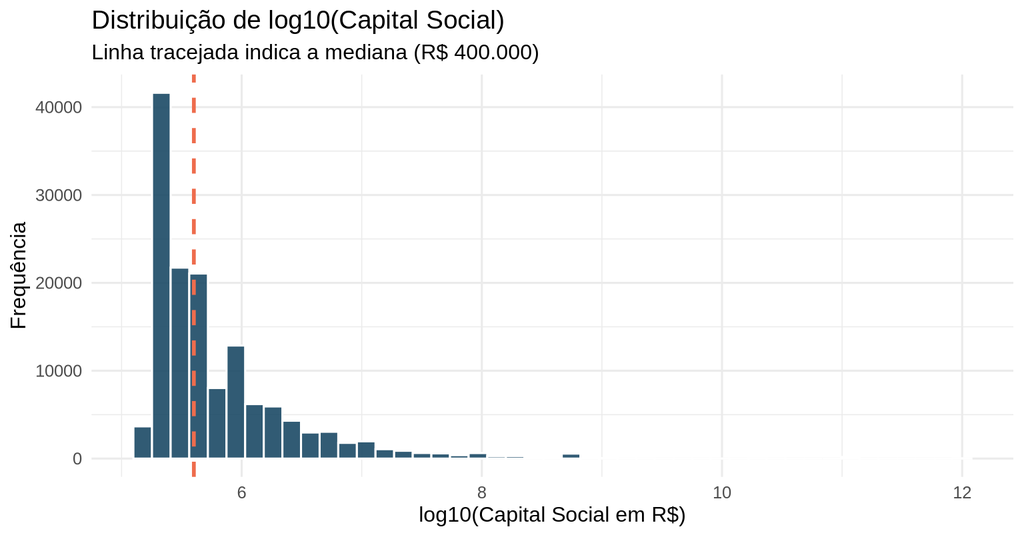

```r
ggplot(companies_df, aes(x = log10_capital)) +
  geom_histogram(bins = 45, fill = PRIMARY_COLOR, color = "white", alpha = 0.9) +
  geom_vline(xintercept = log10(kpis$median_capital), color = ACCENT_COLOR, linetype = "dashed", linewidth = 1) +
  labs(
    title = "Distribuição de log10(Capital Social)",
    subtitle = sprintf("Linha tracejada indica a mediana (%s)", format_brl(kpis$median_capital)),
    x = "log10(Capital Social em R$)",
    y = "Frequência"
  ) +
  theme_minimal(base_size = 12)
```

## 3 Comparação por Porte, Natureza Jurídica e Qualificação

### 3.1 Porte Empresarial (`company_size`)

**Código**

```r
size_summ <- compute_grouped_summary(companies_df, "company_size")
size_summ |>
  dplyr::transmute(
    Porte = grupo,
    Empresas = format(n, big.mark = "."),
    `%` = sprintf("%.2f%%", pct),
    Mediana = format_brl(mediana),
    IQR = format_brl(iqr),
    Média = format_brl(media)
  ) |>
  knitr::kable(caption = "Estatísticas descritivas do capital social por porte empresarial.")
```

Estatísticas descritivas do capital social por porte empresarial.

| Porte | Empresas | % | Mediana | IQR | Média |
| --- | --- | --- | --- | --- | --- |
| micro-enterprise | 66.202 | 46.84% | R$ 300.000 | R$ 300.000 | R$ 21.291.946 |
| other | 42.520 | 30.09% | R$ 1.037.169 | R$ 3.092.722 | R$ 500.429.583 |
| small-enterprise | 32.610 | 23.07% | R$ 350.000 | R$ 495.000 | R$ 837.193.374 |

### 3.2 Natureza Jurídica e Qualificação dos Responsáveis

**Código**

```r
legal_summ <- compute_grouped_summary(companies_df, "legal_nature") |>
  dplyr::slice_head(n = 10)

legal_summ |>
  dplyr::transmute(
    `Natureza Jurídica (Top 10)` = grupo,
    Empresas = format(n, big.mark = "."),
    `%` = sprintf("%.2f%%", pct),
    `% Acumulado` = sprintf("%.2f%%", pct_acumulado),
    Mediana = format_brl(mediana)
  ) |>
  knitr::kable(caption = "Top 10 naturezas jurídicas por quantidade de empresas.")
```

Top 10 naturezas jurídicas por quantidade de empresas.

| Natureza Jurídica (Top 10) | Empresas | % | % Acumulado | Mediana |
| --- | --- | --- | --- | --- |
| Limited Liability Business Company (LLC) | 119.288 | 84.40% | 84.40% | R$ 400.000 |
| Sole Proprietorship | 15.209 | 10.76% | 95.16% | R$ 300.000 |
| Privately Held Corporation | 2.897 | 2.05% | 97.21% | R$ 4.500.000 |
| Silent Partnership | 2.585 | 1.83% | 99.04% | R$ 1.350.000 |
| Simple Limited Partnership | 550 | 0.39% | 99.43% | R$ 500.000 |
| Individual Limited Liability Company (Business) | 182 | 0.13% | 99.56% | R$ 300.000 |
| Simple Innovation Company | 144 | 0.10% | 99.66% | R$ 460.000 |
| Sole Member Law Firm | 123 | 0.09% | 99.75% | R$ 250.000 |
| Simple Partnership (Pure) | 114 | 0.08% | 99.83% | R$ 300.000 |
| Cooperative | 78 | 0.06% | 99.89% | R$ 451.451 |

**Código**

```r
qual_summ <- compute_grouped_summary(companies_df, "owner_qualification") |>
  dplyr::slice_head(n = 10)

qual_summ |>
  dplyr::transmute(
    `Qualificação (Top 10)` = grupo,
    Empresas = format(n, big.mark = "."),
    `%` = sprintf("%.2f%%", pct),
    Mediana = format_brl(mediana)
  ) |>
  knitr::kable(caption = "Top 10 qualificações dos sócios/responsáveis.")
```

Top 10 qualificações dos sócios/responsáveis.

| Qualificação (Top 10) | Empresas | % | Mediana |
| --- | --- | --- | --- |
| Managing Partner / Partner-Administrator | 107.027 | 75.73% | R$ 350.000 |
| Administrator / Manager | 15.236 | 10.78% | R$ 1.250.000 |
| Entrepreneur / Business Owner | 15.201 | 10.76% | R$ 300.000 |
| Director / Officer | 1.634 | 1.16% | R$ 7.000.000 |
| President / Chair | 1.343 | 0.95% | R$ 2.485.843 |
| Beneficial Owner (individual) resident or domiciled in Brazil | 442 | 0.31% | R$ 300.000 |
| Judicial Administrator (Court-appointed) | 302 | 0.21% | R$ 2.784.168 |
| Sole Owner of an Individual Real Estate Company | 50 | 0.04% | R$ 500.000 |
| Ostensible Partner (Managing partner in a silent partnership) | 32 | 0.02% | R$ 950.000 |
| Liquidator | 29 | 0.02% | R$ 2.945.000 |

## 4 Associações Categóricas

Avaliamos a dependência entre `company_size` e `legal_nature` (Top 6 + cauda longa) por meio do teste Qui-quadrado de independência e do V de Cramér.

**Código**

```r
assoc <- compute_contingency_analysis(companies_df, "company_size", "legal_nature", top_k = 6L)
```

- **Estatística $\chi^2$**: 27.333,3
- **p-valor**: < 0,0001
- **V de Cramér**: 0.3110

## 5 Concentração de Capital e Outliers

**Código**

```r
gini_res <- compute_gini_and_lorenz(companies_df$capital_stock)
```

- **Índice de Gini**: 0.9976
- **Participação do Top 1% das empresas**: 99.23% do capital social total.
- **Participação do Top 10% das empresas**: 99.84% do capital social total.

**Código**

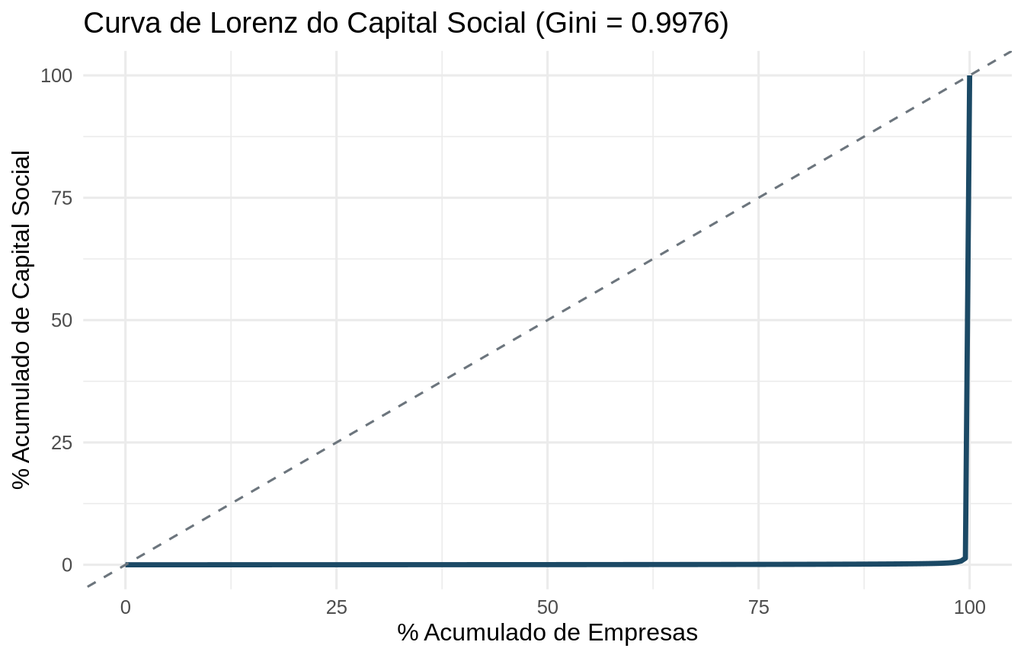

```r
ggplot(gini_res$lorenz_df, aes(x = p * 100, y = lorenz * 100)) +
  geom_line(color = PRIMARY_COLOR, linewidth = 1.2) +
  geom_abline(slope = 1, intercept = 0, linetype = "dashed", color = MUTED_COLOR) +
  labs(
    title = sprintf("Curva de Lorenz do Capital Social (Gini = %.4f)", gini_res$gini),
    x = "% Acumulado de Empresas",
    y = "% Acumulado de Capital Social"
  ) +
  theme_minimal(base_size = 12)
```

## 6 Padrões de Nomenclatura (`company_name`)

**Código**

```r
suffix_summ <- compute_grouped_summary(companies_df, "legal_suffix")
suffix_summ |>
  dplyr::transmute(
    `Sufixo Societário` = grupo,
    Empresas = format(n, big.mark = "."),
    `%` = sprintf("%.2f%%", pct),
    Mediana = format_brl(mediana)
  ) |>
  knitr::kable(caption = "Distribuição de sufixos societários extraídos da razão social.")
```

Distribuição de sufixos societários extraídos da razão social.

| Sufixo Societário | Empresas | % | Mediana |
| --- | --- | --- | --- |
| LTDA / Limitada | 121.513 | 85.98% | R$ 400.000 |
| Outros / Sem sufixo | 16.786 | 11.88% | R$ 300.000 |
| S/A | 2.842 | 2.01% | R$ 4.295.350 |
| EIRELI | 188 | 0.13% | R$ 300.000 |
| Unipessoal / SLU | 2 | 0.00% | R$ 81.465.495 |
| ME (sufixo) | 1 | 0.00% | R$ 500.000 |

## 7 Testes Estatísticos Não Paramétricos

Dada a forte assimetria de `capital_stock`, aplicamos o teste de **Kruskal-Wallis** com tamanho de efeito $\epsilon^2$ e comparações múltiplas pareadas com correção de **Holm-Bonferroni**.

**Código**

```r
kw_size <- run_nonparametric_tests(companies_df, "company_size", p_adjust_method = "holm")
knitr::kable(kw_size$omnibus, caption = "Teste omnibus de Kruskal-Wallis para capital_stock por porte.")
```

Teste omnibus de Kruskal-Wallis para capital_stock por porte.

| teste | fator | grupos | estatistica_h | gl | p_valor | epsilon_quadrado |
| --- | --- | --- | --- | --- | --- | --- |
| Kruskal-Wallis | company_size | 3 | 27486.81 | 2 | 0 | 0.1944854 |

**Código**

```r
kw_size$pairwise |>
  dplyr::transmute(
    `Grupo 1` = grupo_1,
    `Grupo 2` = grupo_2,
    `Mediana 1` = format_brl(mediana_1),
    `Mediana 2` = format_brl(mediana_2),
    `p-ajustado (Holm)` = ifelse(p_ajustado < 1e-4, "< 0,0001", sprintf("%.4f", p_ajustado))
  ) |>
  knitr::kable(caption = "Comparações pareadas pós-hoc entre portes empresariais.")
```

Comparações pareadas pós-hoc entre portes empresariais.

| Grupo 1 | Grupo 2 | Mediana 1 | Mediana 2 | p-ajustado (Holm) |
| --- | --- | --- | --- | --- |
| small-enterprise | micro-enterprise | R$ 350.000 | R$ 300.000 | < 0,0001 |
| other | micro-enterprise | R$ 1.037.169 | R$ 300.000 | < 0,0001 |
| other | small-enterprise | R$ 1.037.169 | R$ 350.000 | < 0,0001 |

## 8 Conclusões

1. **Concentração Estrutural**: A base é dominada por `Limited Liability Business Company (LLC)` (84,40%) e pelo porte `micro-enterprise` (46,84%).
2. **Desigualdade Extrema de Capital**: Embora a mediana seja de R$ 400.000, o coeficiente de Gini de 0.9976 e a concentração no Top 1% evidenciam uma cauda longa altamente capitalizada.
3. **Diferenças Estatisticamente Significativas**: Os testes não paramétricos confirmam diferenças significativas de capital social entre todos os portes empresariais ($p < 0,0001$ após correção de Holm).